# Topic 4 Exercises: Classification

## 4.7.1

(4.2) <- p(X) = eβ0+β1X/(1+eβ0+β1X) (4.3) <- p(X)/(1−p(X)) = eβ0+β1X

If we want to prove that they’re equivalent, we first set eβ0+β1X to y. That means (4.2) <- P(X) = Y/(1+Y) <- P(X)(1+Y) = Y <- P(X)+P(X)Y = Y <- P(X) = Y-P(X)Y <-  
P(X) = Y(1-P(X)) <- P(X)/(1-P(X)) = Y

Plug eβ0+β1X back in and you get P(X)/(1-P(X)) = eβ0+β1X which is (4.3)

## 4.7.8

When we use the KNN method with K=1, we know that the training error rate is 0% because P(Y=j|X=xi)=I(yi=j). This means that the test error rate can be as high as 36% since the average error is 18%. Since the test error rate for KNN (36%) is most likely higher than the error for logistic regression (30%), we would prefer the logistic regression method.

## 4.7.9

1. Odds = P(X)/(1-P(X)) -> 0.37 = P(X)/(1-P(X)) -> 0.37 = 1.37P(X) -> P(X) = 0.27. On average, 27% of people default.
2. Odds = P(X)/(1-P(X)) -> Odds = 0.16/0.84 = 0.19 The odds that she will default are 19%.

## 4.7.11

```r
##part a
library(ISLR)
library(MASS)
#Auto <- read.csv("/home/local/MAC/jpark2/Math-253-Assignments/Auto.csv")

Auto$mpg01 <- with(ifelse(mpg > median(mpg), 1, 0), data=Auto)
```

## part b

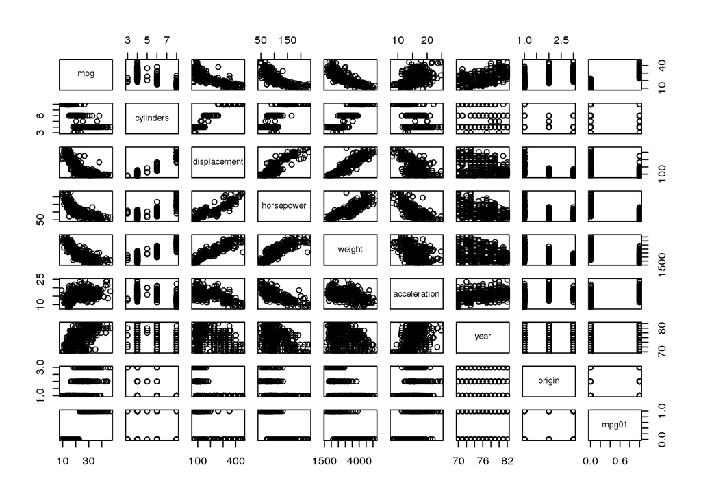

```r
pairs(Auto[,-9])
```

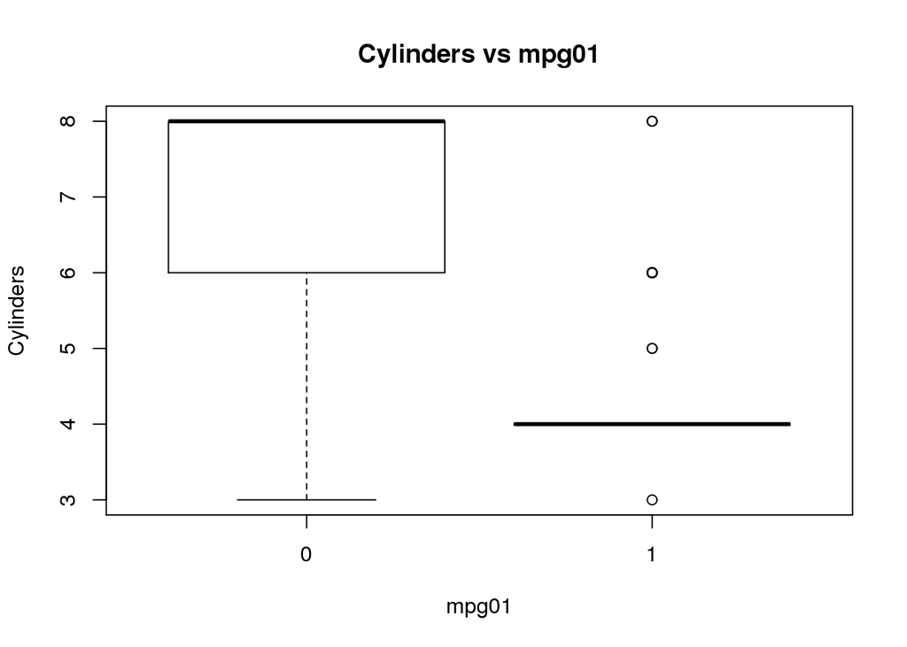

```r
boxplot(with(Auto, cylinders ~ mpg01), main = "Cylinders vs mpg01", xlab = "mpg01", ylab = "Cylinders")
```

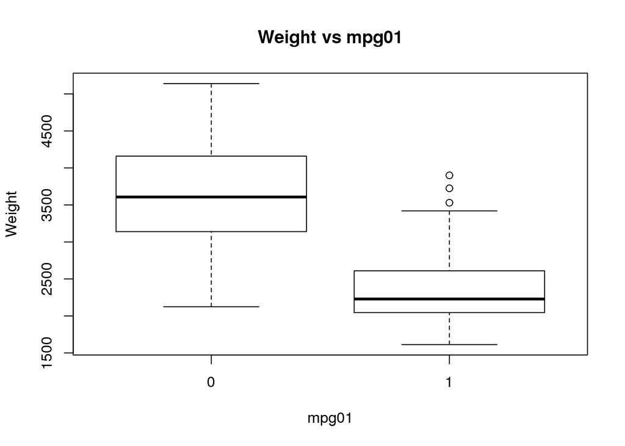

```r
boxplot(Auto$weight ~ Auto$mpg01, main = "Weight vs mpg01", xlab = "mpg01", ylab = "Weight")
```

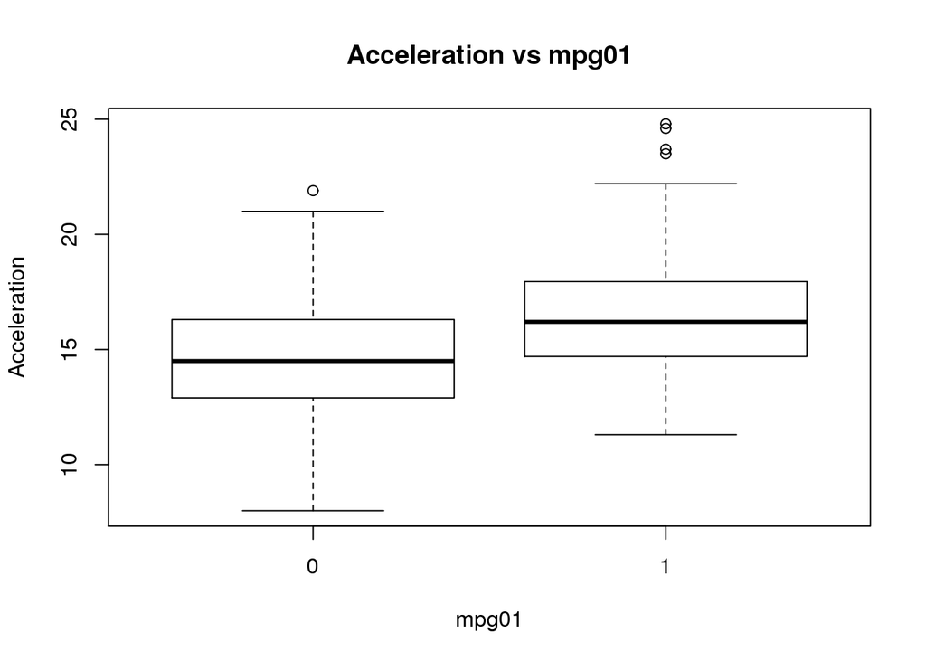

```r
boxplot(Auto$acceleration ~ Auto$mpg01, main = "Acceleration vs mpg01", xlab = "mpg01", ylab = "Acceleration")
```

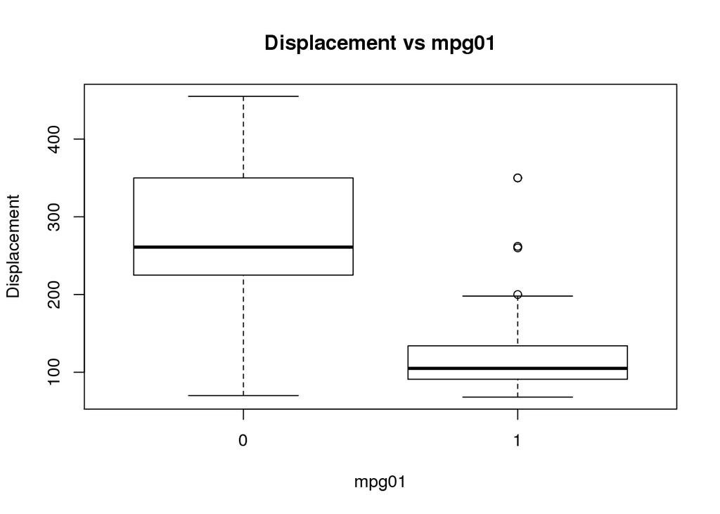

```r
boxplot(Auto$displacement ~ Auto$mpg01, main = "Displacement vs mpg01", xlab = "mpg01", ylab = "Displacement")
```

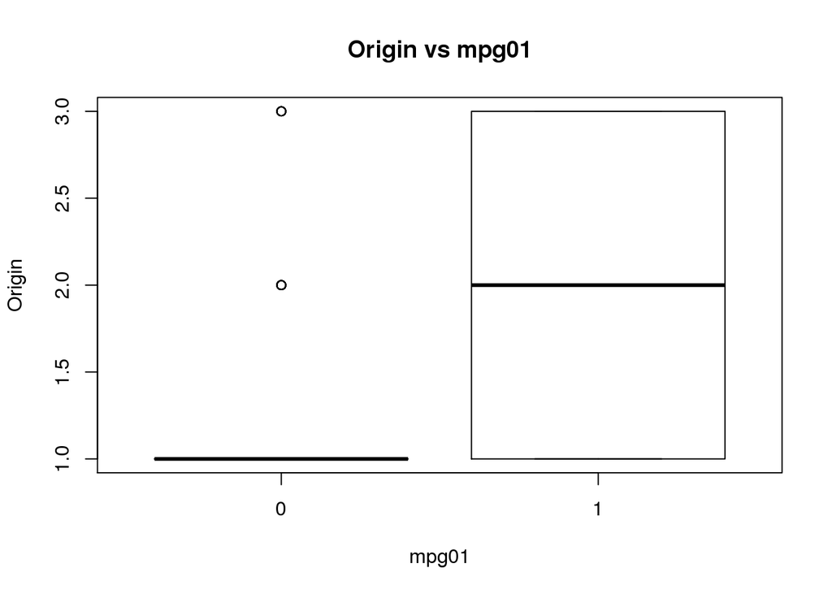

```r
boxplot(Auto$origin ~ Auto$mpg01, main = "Origin vs mpg01", xlab = "mpg01", ylab = "Origin")
```

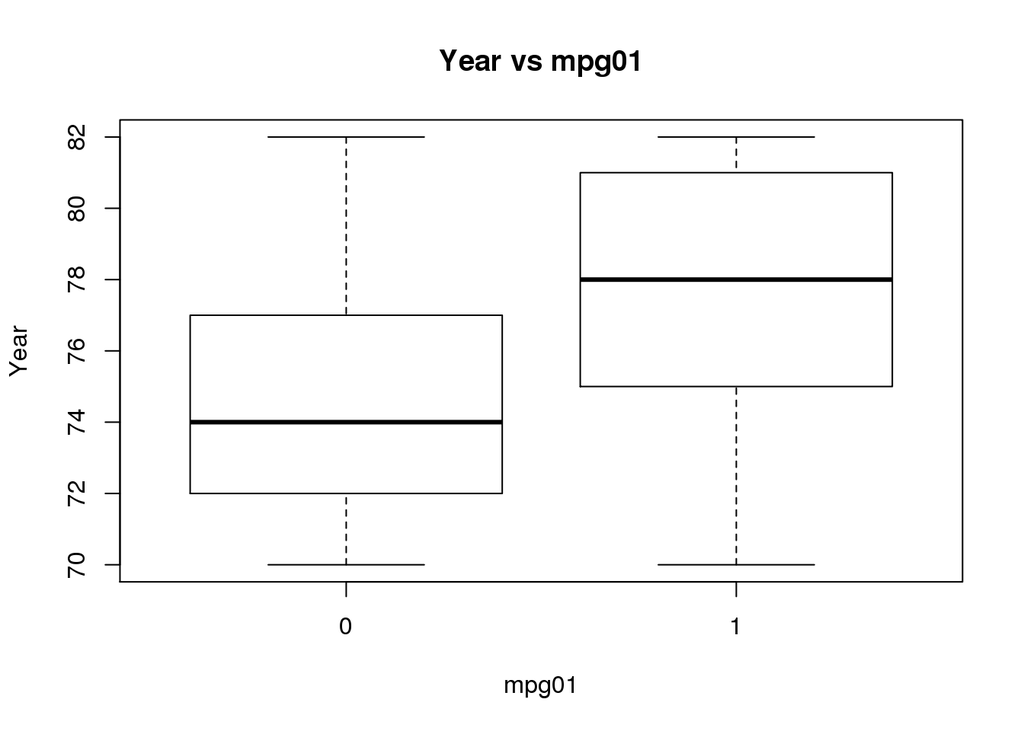

```r
boxplot(Auto$year ~ Auto$mpg01, main = "Year vs mpg01", xlab = "mpg01", ylab = "Year")
```

#We may conclude that there exists some association between “mpg01” and “cylinders”, “weight”, “displacement”.

## part c

```r
set.seed(1)
inds <- sample(1:nrow(Auto), size = nrow(Auto)/2)
trainSet <- Auto[inds, ]
testSet <- Auto[-inds, ]
```

## part d

```r
lda.fit <- lda(mpg01 ~ displacement + weight + cylinders, data = trainSet)
lda.pred <- predict(lda.fit, testSet)
table(testSet$mpg01, lda.pred$class)
```

```
##
##      0  1
##   0 78 15
##   1  5 98
```

```r
sum(lda.pred$class!=testSet$mpg01)/nrow(testSet)
```

```
## [1] 0.1020408
```

## We have a test error rate of around 10.2%

## part e

```r
qda.fit <- qda(mpg01 ~ displacement + weight + cylinders, data = trainSet)
qda.pred <- predict(qda.fit, testSet)
table(testSet$mpg01, qda.pred$class)
```

```
##
##      0  1
##   0 83 10
##   1  8 95
```

```r
sum(qda.pred$class != testSet$mpg01)/nrow(testSet)
```

```
## [1] 0.09183673
```

## We have a test error rate of around 9.18%

## part f

```r
logReg <- glm(mpg01 ~ displacement + weight + cylinders, data = trainSet, family = "binomial")
summary(logReg)
```

```
##
## Call:
## glm(formula = mpg01 ~ displacement + weight + cylinders, family = "binomial",
##     data = trainSet)
##
## Deviance Residuals:
##      Min        1Q    Median        3Q       Max
## -2.49178  -0.42519  -0.05882   0.44560   2.86218
##
## Coefficients:
##                Estimate Std. Error z value Pr(>|z|)
## (Intercept)   9.9511752  1.9212875   5.179 2.23e-07 ***
## displacement -0.0024427  0.0097014  -0.252  0.80120
## weight       -0.0026920  0.0008814  -3.054  0.00226 **
## cylinders    -0.3345685  0.4167634  -0.803  0.42210
## ---
## Signif. codes:  0 '***' 0.001 '**' 0.01 '*' 0.05 '.' 0.1 ' ' 1
##
## (Dispersion parameter for binomial family taken to be 1)
##
##     Null deviance: 271.20  on 195  degrees of freedom
## Residual deviance: 125.93  on 192  degrees of freedom
## AIC: 133.93
##
## Number of Fisher Scoring iterations: 6
```

```r
logReg.probs <- predict(logReg, testSet, type="response")
logReg.pred <- ifelse(logReg.probs > 0.5, 1, 0)
table(logReg.pred, testSet$mpg01)
```

```
##
## logReg.pred  0  1
##           0 79  6
##           1 14 97
```

```r
mean(logReg.pred != testSet$mpg01)
```

```
## [1] 0.1020408
```

## We have a test error rate of around 10.2%

## part g

```r
set.seed(1)
training <- trainSet[,c("displacement", "weight", "cylinders")]
testing <- testSet[,c("displacement", "weight", "cylinders")]
library(class)
knn.pred <- class::knn(training, testing, trainSet$mpg01, k = 1)
table(knn.pred, testSet$mpg01)
```

```
##
## knn.pred  0  1
##        0 76  7
##        1 17 96
```

```r
mean(knn.pred != testSet$mpg01)
```

```
## [1] 0.122449
```

```r
knn.pred <- class::knn(training, testing, trainSet$mpg01, k = 2)
table(knn.pred, testSet$mpg01)
```

```
##
## knn.pred  0  1
##        0 73  9
##        1 20 94
```

```r
mean(knn.pred != testSet$mpg01)
```

```
## [1] 0.1479592
```

```r
knn.pred <- class::knn(training, testing, trainSet$mpg01, k = 3)
table(knn.pred, testSet$mpg01)
```

```
##
## knn.pred  0  1
##        0 77  6
##        1 16 97
```

```r
mean(knn.pred != testSet$mpg01)
```

```
## [1] 0.1122449
```

```r
knn.pred <- class::knn(training, testing, trainSet$mpg01, k = 4)
table(knn.pred, testSet$mpg01)
```

```
##
## knn.pred  0  1
##        0 75  6
##        1 18 97
```

```r
mean(knn.pred != testSet$mpg01)
```

```
## [1] 0.122449
```

```r
knn.pred <- class::knn(training, testing, trainSet$mpg01, k = 5)
table(knn.pred, testSet$mpg01)
```

```
##
## knn.pred  0  1
##        0 75  4
##        1 18 99
```

```r
mean(knn.pred != testSet$mpg01)
```

```
## [1] 0.1122449
```

```r
knn.pred <- class::knn(training, testing, trainSet$mpg01, k = 6)
table(knn.pred, testSet$mpg01)
```

```
##
## knn.pred  0  1
##        0 75  6
##        1 18 97
```

```r
mean(knn.pred != testSet$mpg01)
```

```
## [1] 0.122449
```

```r
knn.pred <- class::knn(training, testing, trainSet$mpg01, k = 7)
table(knn.pred, testSet$mpg01)
```

```
##
## knn.pred   0   1
##        0  76   3
##        1  17 100
```

```r
mean(knn.pred != testSet$mpg01)
```

```
## [1] 0.1020408
```

```r
knn.pred <- class::knn(training, testing, trainSet$mpg01, k = 8)
table(knn.pred, testSet$mpg01)
```

```
##
## knn.pred  0  1
##        0 74  5
##        1 19 98
```

```r
mean(knn.pred != testSet$mpg01)
```

```
## [1] 0.122449
```

```r
knn.pred <- class::knn(training, testing, trainSet$mpg01, k = 9)
table(knn.pred, testSet$mpg01)
```

```
##
## knn.pred   0   1
##        0  73   3
##        1  20 100
```

```r
mean(knn.pred != testSet$mpg01)
```

```
## [1] 0.1173469
```

```r
knn.pred <- class::knn(training, testing, trainSet$mpg01, k = 10)
table(knn.pred, testSet$mpg01)
```

```
##
## knn.pred   0   1
##        0  73   3
##        1  20 100
```

```r
mean(knn.pred != testSet$mpg01)
```

```
## [1] 0.1173469
```

## Around K=7

## 4.7.13

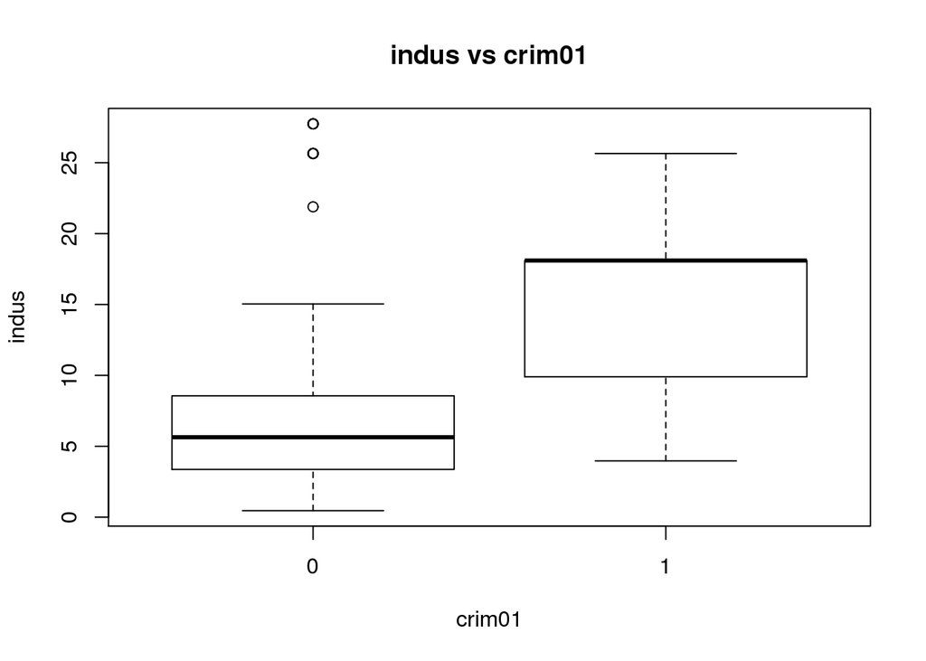

```r
library(MASS)
Boston$crim01 <- ifelse(Boston$crim > median(Boston$crim), 1, 0)
boxplot(with(Boston, indus ~ crim01), main = "indus vs crim01", xlab = "crim01", ylab = "indus")
```

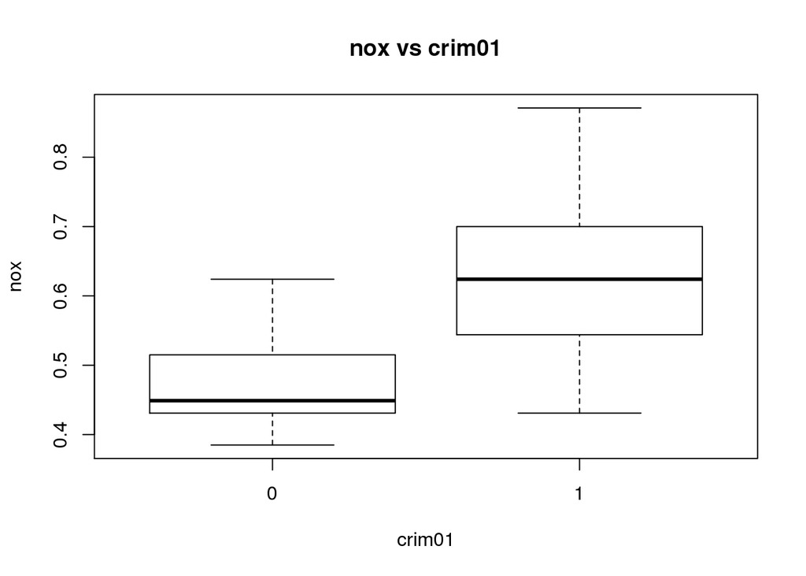

```r
boxplot(with(Boston, nox ~ crim01), main = "nox vs crim01", xlab = "crim01", ylab = "nox")
```

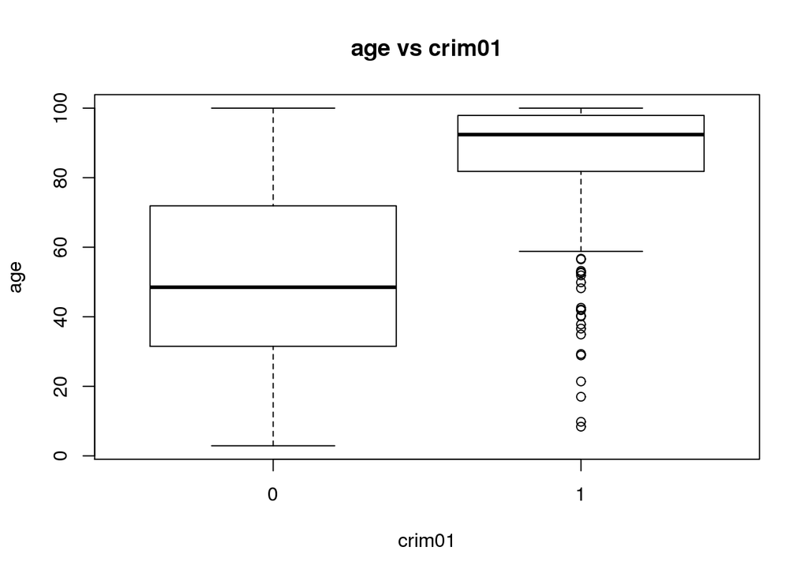

```r
boxplot(with(Boston, age ~ crim01), main = "age vs crim01", xlab = "crim01", ylab = "age")
```

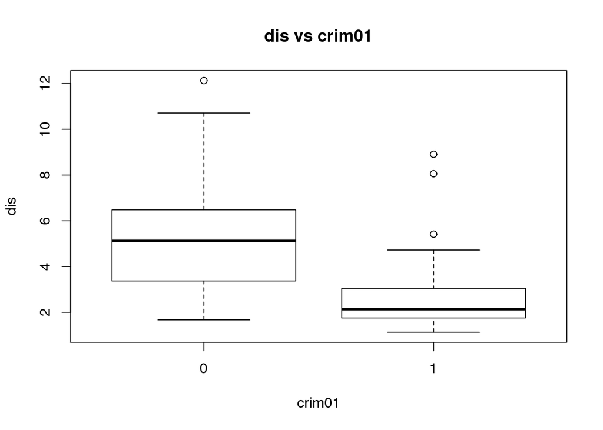

```r
boxplot(with(Boston, dis ~ crim01), main = "dis vs crim01", xlab = "crim01", ylab = "dis")
```

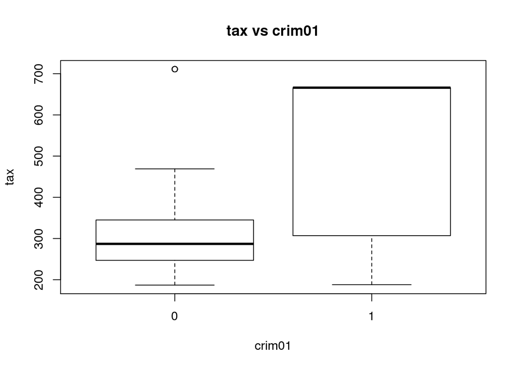

```r
boxplot(with(Boston, tax ~ crim01), main = "tax vs crim01", xlab = "crim01", ylab = "tax")
```

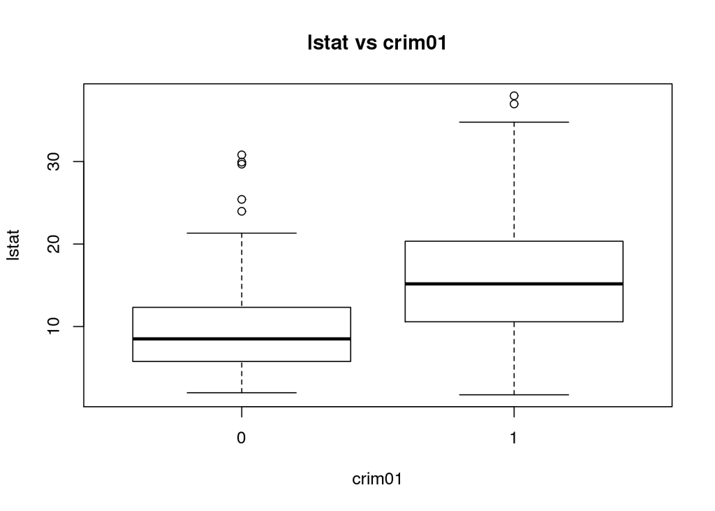

```r
boxplot(with(Boston, lstat ~ crim01), main = "lstat vs crim01", xlab = "crim01", ylab = "lstat")
```

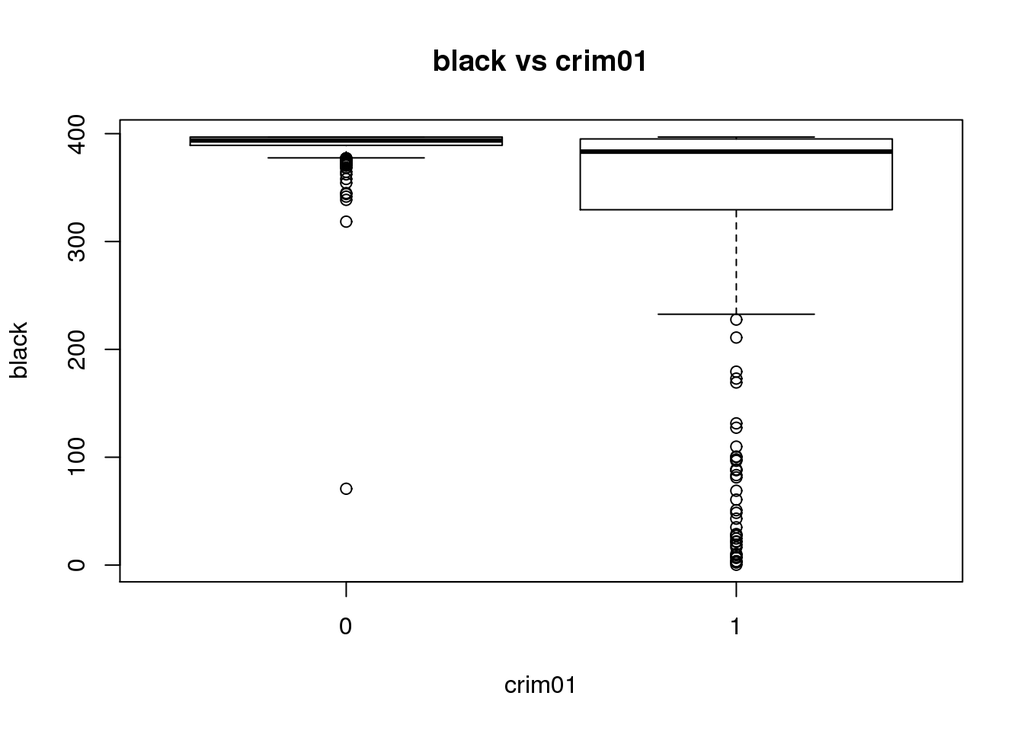

```r
boxplot(with(Boston, black ~ crim01), main = "black vs crim01", xlab = "crim01", ylab = "black")
```

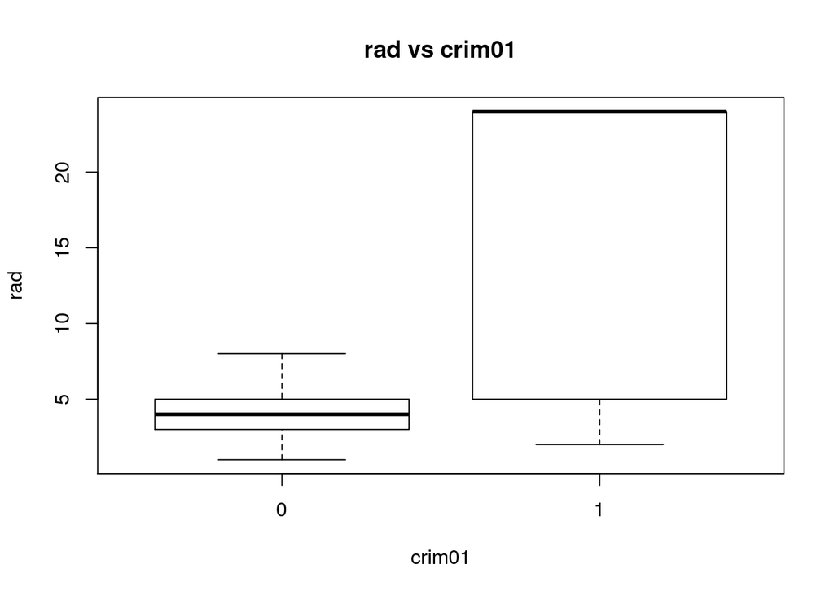

```r
boxplot(with(Boston, rad ~ crim01), main = "rad vs crim01", xlab = "crim01", ylab = "rad")
```

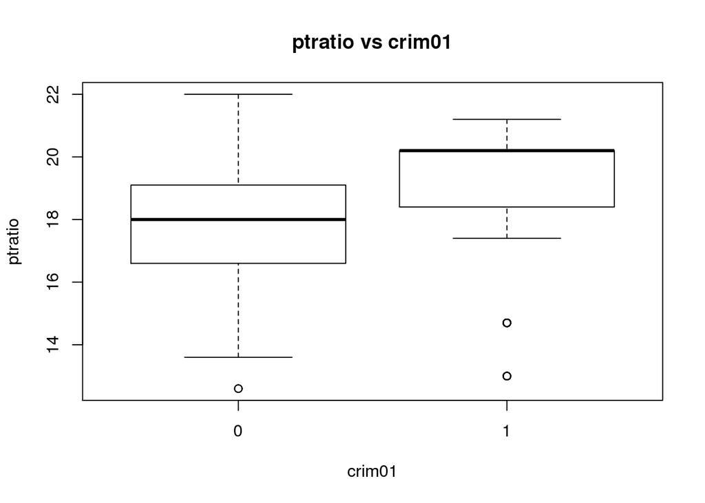

```r
boxplot(with(Boston, ptratio ~ crim01), main = "ptratio vs crim01", xlab = "crim01", ylab = "ptratio")
```

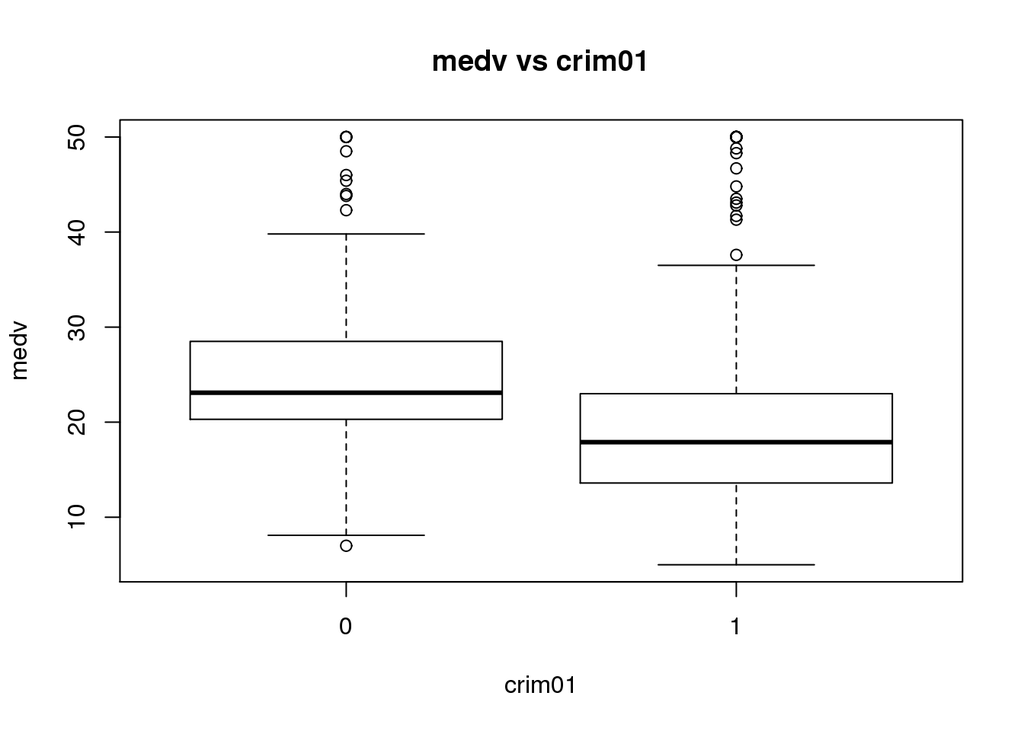

```r
boxplot(with(Boston, medv ~ crim01), main = "medv vs crim01", xlab = "crim01", ylab = "medv")
```

```r
set.seed(1)
inds1 <- sample(1:nrow(Boston), size = nrow(Boston)/2)
boston.train <- Boston[inds1, ]
boston.test <- Boston[-inds1, ]


#LDA Model = 16.99% Test Error
lda.fit1 <- lda(crim01 ~ zn + indus + nox + age + dis + tax + lstat + black +  rad + ptratio + medv, data = boston.train)
lda.pred1 <- predict(lda.fit1, boston.test)

mean(lda.pred1$class!=boston.test$crim01)
```

```
## [1] 0.1699605
```

```r
#Logistic Regression = 11.86% Test Error
logreg1 <- glm(crim01 ~ zn + indus + nox + age + dis + tax + lstat + black +  rad + ptratio + medv, data = boston.train, family = "binomial")
summary(logreg1)
```

```
##
## Call:
## glm(formula = crim01 ~ zn + indus + nox + age + dis + tax + lstat +
##     black + rad + ptratio + medv, family = "binomial", data = boston.train)
##
## Deviance Residuals:
##     Min       1Q   Median       3Q      Max
## -1.6069  -0.1759  -0.0027   0.0037   3.5233
##
## Coefficients:
##               Estimate Std. Error z value Pr(>|z|)
## (Intercept) -43.963270  10.127991  -4.341 1.42e-05 ***
## zn           -0.044627   0.039773  -1.122  0.26185
## indus        -0.076451   0.068382  -1.118  0.26357
## nox          53.296102  11.768607   4.529 5.94e-06 ***
## age           0.051164   0.016714   3.061  0.00221 **
## dis           0.822878   0.330170   2.492  0.01269 *
## tax          -0.007687   0.004258  -1.805  0.07102 .
## lstat         0.059105   0.072620   0.814  0.41570
## black        -0.004348   0.005462  -0.796  0.42603
## rad           0.535341   0.216146   2.477  0.01326 *
## ptratio       0.346150   0.168085   2.059  0.03946 *
## medv          0.153850   0.064870   2.372  0.01771 *
## ---
## Signif. codes:  0 '***' 0.001 '**' 0.01 '*' 0.05 '.' 0.1 ' ' 1
##
## (Dispersion parameter for binomial family taken to be 1)
##
##     Null deviance: 350.73  on 252  degrees of freedom
## Residual deviance:  94.71  on 241  degrees of freedom
## AIC: 118.71
##
## Number of Fisher Scoring iterations: 9
```

```r
logreg.probs <- predict(logreg1, boston.test, type="response")
logreg.pred <- ifelse(logreg.probs > 0.5, 1, 0)

mean(logreg.pred != boston.test$crim01)
```

```
## [1] 0.1185771
```

```r
#KNN Model = 9.09% Test Error
trainingBoston <- boston.train[,c("zn", "indus", "nox", "age", "dis", "tax", "lstat", "black", "rad", "ptratio", "medv")]
testingBoston <- boston.test[,c("zn", "indus", "nox", "age", "dis", "tax", "lstat", "black", "rad", "ptratio", "medv")]
knn.pred <- class::knn(trainingBoston, testingBoston, boston.train$crim01, k=1)
table(knn.pred, boston.test$crim01)
```

```
##
## knn.pred   0   1
##        0 114  11
##        1  12 116
```

```r
mean(knn.pred != boston.test$crim01)
```

```
## [1] 0.09090909
```